# Help Zomato Predict Rating from the Review

# Use train-test method

```python
from sklearn.model_selection import train_test_split
```

```python
X_train, X_test, y_train, y_test = train_test_split(X, y, test_size = 0.3, random_state=42)
```

# 5. Use TF-IDF values for the terms as features to get into a vector space model

a. Import TF-IDF vectorizer from sklearn

b. Instantiate with a maximum of 5000 terms in your vocabulary

c. Fit and apply on the train set

d. Apply on the test set

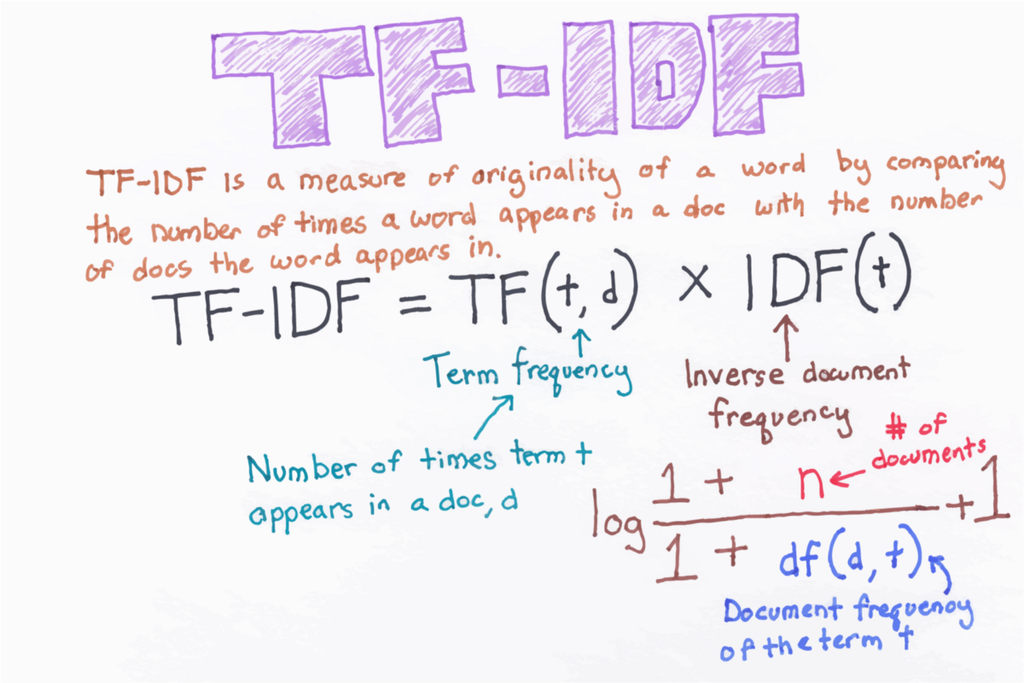

```python
from sklearn.feature_extraction.text import TfidfVectorizer
```

```python
vectorizer = TfidfVectorizer(max_features = 5000)
```

```python
len(X_train), len(X_test)
```

```
(19423, 8325)
```

```python
X_train_bow = vectorizer.fit_transform(X_train)
```

```python
X_test_bow = vectorizer.transform(X_test)
```

```python
X_train_bow.shape, X_test_bow.shape
```

```
((19423, 5000), (8325, 5000))
```

# 6. Model building: Random Forest Regressor

a. Instantiate RandomForestRegressor from sklearn (set random seed)

b. Fit on the train data

c. Make predictions for the train set

```python
from sklearn.ensemble import RandomForestRegressor
from sklearn.ensemble import GradientBoostingRegressor
from sklearn.metrics import mean_squared_error
```

# Check Parameter For RandomForestRegressor

```python
#?RandomForestRegressor
```

```python
randomF_Learner = RandomForestRegressor(random_state=42)
```

```python
%%time
randomF_Learner.fit(X_train_bow, y_train)
```

```
Wall time: 6min 21s
```

```
RandomForestRegressor(random_state=42)
```

```python
y_train_preds = randomF_Learner.predict(X_train_bow)
```

# 7. Model evaluation

a. Report the root mean square error

```python
mean_squared_error(y_train, y_train_preds)**0.5
```

```
0.23720347586757728
```

```python
randomF_Learner = RandomForestRegressor(random_state=42, n_estimators=20)
```

```python
%%time
randomF_Learner.fit(X_train_bow, y_train)
```

```
Wall time: 1min 15s
```

```
RandomForestRegressor(n_estimators=20, random_state=42)
```

```python
y_train_preds = randomF_Learner.predict(X_train_bow)
```

# 7. Model evaluation

a. Report the root mean square error

```python
mean_squared_error(y_train, y_train_preds)**0.5
```

```
0.2507584827360229
```

# 8. Hyperparameter tuning

a. Import GridSearch

b. Provide the parameter grid to choose:

i. max_features – ‘auto’, ‘sqrt’, ‘log2’

ii. max_depth – 10, 15, 20, 25

```python
from sklearn.model_selection import GridSearchCV
```

```python
learner_rf = RandomForestRegressor(random_state=42)
```

```python
# Create the parameter grid based on the results of random search
param_grid = {
    'max_features': [500, "sqrt", "log2", "auto"],
    'max_depth': [10, 15, 20, 25]
}
```

# 9. Find the parameters with the best mean square error in cross-validation

a. Choose the appropriate scoring as the metric for scoring

b. Choose stratified 5 fold cross-validation scheme

c. Fit on the train set

```python
# Instantiate the grid search model
grid_search = GridSearchCV(estimator = learner_rf, param_grid = param_grid,
                          cv = 5, n_jobs = -1, verbose = 1, scoring = "neg_mean_squared_error" )
```

```python
grid_search.fit(X_train_bow, y_train)
```

```
Fitting 5 folds for each of 16 candidates, totalling 80 fits
```

```
GridSearchCV(cv=5, estimator=RandomForestRegressor(random_state=42), n_jobs=-1,
             param_grid={'max_depth': [10, 15, 20, 25],
                         'max_features': [500, 'sqrt', 'log2', 'auto']},
             scoring='neg_mean_squared_error', verbose=1)
```

```python
grid_search.cv_results_
```

[output not shown]

[output cut: 19 more lines]

[output not shown]

# 10. What are the best parameters?

# 11. Predict and evaluate using the best estimator

a. Use the best estimator from the grid search to make predictions on the test set

b. What is the root mean squared error on the test set?

```python
grid_search.best_estimator_
```

```
RandomForestRegressor(max_depth=25, max_features=500, random_state=42)
```

```python
y_train_pred = grid_search.best_estimator_.predict(X_train_bow)
```

```python
y_test_pred = grid_search.best_estimator_.predict(X_test_bow)
```

```python
mean_squared_error(y_train, y_train_pred)**0.5
```

```
0.5876681060137491
```

```python
mean_squared_error(y_test, y_test_pred)**0.5
```

```
0.6715338514796404
```

# 12. Can you identify mismatch cases?

a. Make a rule based on the predicted value and the actual value that identifies mismatch

cases (e.g. difference in actual and predicted being more than a cutoff)

b. How many such cases do you see?

c. Are all these mismatch cases genuine?

```python
rev = pd.DataFrame({'review':X_test, 'rating':y_test, 'rating_pred':y_test_pred})
```

```python
rev[(rev.rating - rev.rating_pred)>=2].shape
```

```
(8, 3)
```

```python
rev[(rev.rating - rev.rating_pred)>=2]
```

|  | review | rating | rating_pred |
| --- | --- | --- | --- |
| 7277 | life saviours serving excellent food worst tim... | 5.0 | 2.007670 |
| 1818 | value money ordered second time | 5.0 | 2.970624 |
| 4771 | not good | 5.0 | 1.998553 |
| 16510 | may not polished serving packaging etc never b... | 5.0 | 1.894671 |
| 14845 | oh memories place first drink bangalore almost... | 5.0 | 2.628792 |
| 15201 | sauce not included | 4.0 | 1.878766 |
| 3165 | rice quantity less | 5.0 | 2.844196 |
| 16515 | may not polished serving packaging etc never b... | 5.0 | 1.894671 |